# Code Challenging IV

Amanda Chaves

2026-02-19

[Noel, Z.A., Roze, L.V., Breunig, M., Trail, F. 2022. Endophytic fungi as promising biocontrol agent to protect wheat from Fusarium graminearum head blight. Plant Disease.](https://doi.org/10.1094/PDIS-06-21-1253-RE)

This assignment will help you practice integrating markdown into your R scripts for literate programming. It will also involve some more practice with GitHub. You may collaborate with a partner to enhance your learning experience. Please ensure the following:

- Collaboration: If you work with a partner, include both names on the final submission by editing the YAML header.
- Submission: Each person should still submit an assignment to canvas in a Word document, html, or .pdf file generated through R markdown. Additionally, you should provide a link to your GitHub, where the assignment should be viewable by rendering it as a GitHub-flavored markdown file.
- Setup: It is also assumed you already have a GitHub repository for this class.

# Code challenging IV

## Question 1

1. 4 pts. Explain the following:
1. YAML header

A- Is the section at the top of an R Markdown or Markdown document that is enclosed between —— lines. It contains the document’s metadata and configuration settings, such as the title, author, date, and output format

2. Literate programming

A- A programming style that includes coding along with annotations, to make it more readable for humans.

## Question 2

2. 6 pts. Take the code you wrote for coding challenge 3, question 5, and incorporate it into your R markdown file. Some of you have already been doing this, which is great! Your final R markdown file should have the following elements.
1. At the top of the document, make a clickable link to the manuscript where these data are published. The link is here:  
   i. Noel, Z.A., Roze, L.V., Breunig, M., Trail, F. 2022. Endophytic fungi as promising biocontrol agent to protect wheat from Fusarium graminearum head blight. Plant Disease. https://doi.org/10.1094/PDIS-06-21-1253-RE
2. Read the data using a relative file path with na.strings option set to “na”. This means you need to put the Mycotoxin.csv file we have used for the past two weeks into your directory, which git tracks.

```r
library(tidyverse)
mycotoxin <- read_csv("MycotoxinData.csv", na = "na")
```

3. Make a separate code chunk for the figures plotting the DON data, 15ADON, and Seedmass, and one for the three combined using ggarrange.

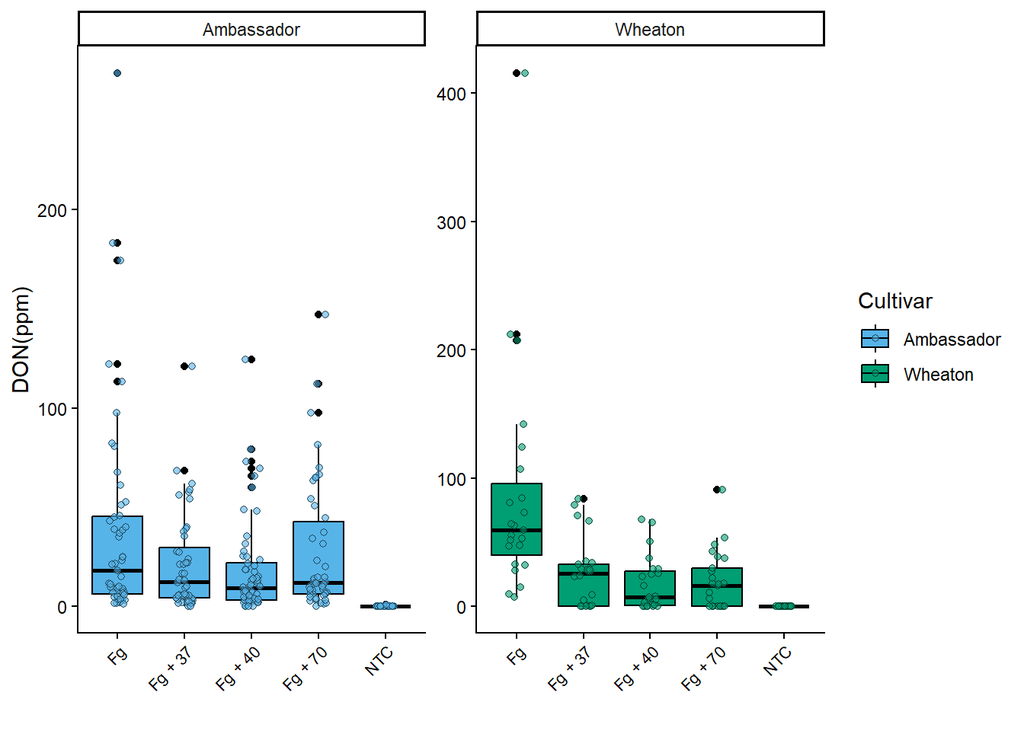

```r
DON.plot <- ggplot(mycotoxin, aes(x = Treatment, y = DON, color = Cultivar, fill = Cultivar))+
  geom_boxplot() +
  geom_jitter(shape = 21, color = "black", alpha = 0.6,
              position = position_jitterdodge()) +
  facet_wrap(~Cultivar, scales = "free") +
  theme_classic()+
  theme(axis.text.x = element_text(size = 8, angle = 45, hjust = 1))+
  scale_color_manual(values = c(cbbPalette[[1]], cbbPalette[[1]]))+
  scale_fill_manual(values = c(cbbPalette[[3]], cbbPalette[[4]]))+
  xlab("")+
  ylab("DON(ppm)")
DON.plot
```

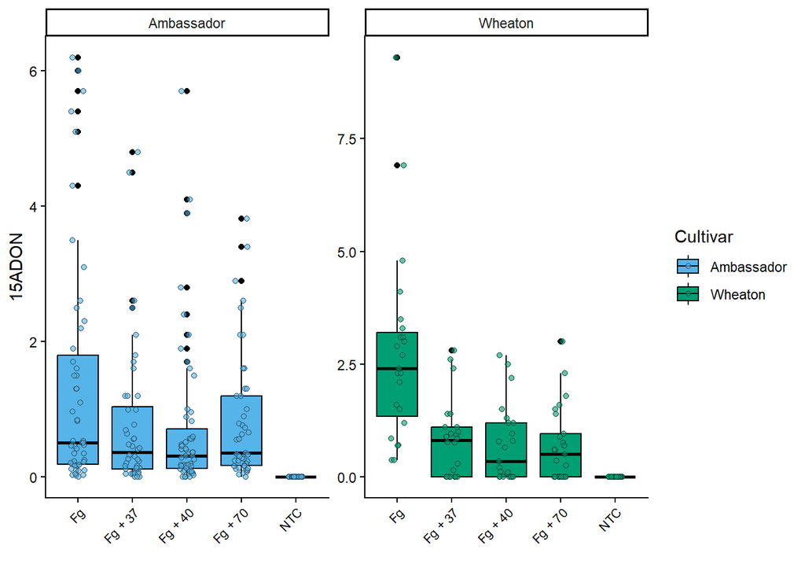

```r
X15ADON.plot <- ggplot(mycotoxin, aes(x = Treatment, y = X15ADON, color = Cultivar, fill = Cultivar))+
  geom_boxplot() +
  geom_jitter(shape = 21, color = "black", alpha = 0.6,
              position = position_jitterdodge()) +
  facet_wrap(~Cultivar, scales = "free") +
  theme_classic()+
  theme(axis.text.x = element_text(size = 8, angle = 45, hjust = 1))+
  scale_color_manual(values = c(cbbPalette[[1]], cbbPalette[[1]]))+
  scale_fill_manual(values = c(cbbPalette[[3]], cbbPalette[[4]]))+
  xlab("")+
  ylab("15ADON")
X15ADON.plot
```

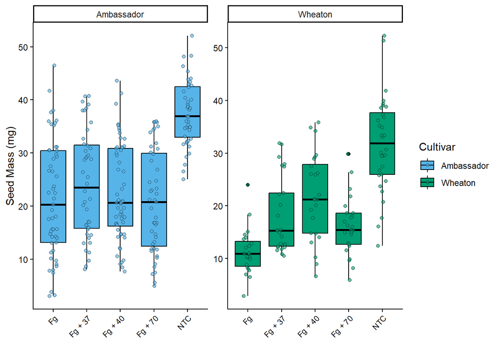

```r
MassperSeed_mg.plot <- ggplot(mycotoxin, aes(x = Treatment, y = MassperSeed_mg, color = Cultivar, fill = Cultivar))+
  geom_boxplot() +
  geom_jitter(shape = 21, color = "black", alpha = 0.6,
              position = position_jitterdodge()) +
  facet_wrap(~Cultivar, scales = "free") +
  theme_classic()+
  theme(axis.text.x = element_text(size = 8, angle = 45, hjust = 1))+
  scale_color_manual(values = c(cbbPalette[[1]], cbbPalette[[1]]))+
  scale_fill_manual(values = c(cbbPalette[[3]], cbbPalette[[4]]))+
  xlab("")+
  ylab("Seed Mass (mg)")
MassperSeed_mg.plot
```

```r
library(ggpubr)
```

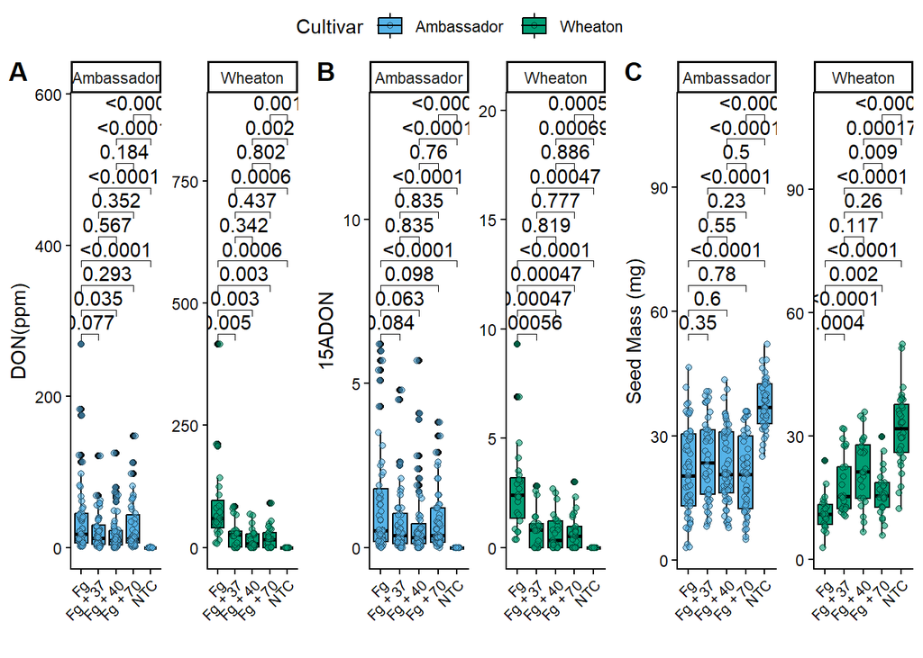

```r
plot1 <- DON.plot+
 geom_pwc(aes(group = Treatment), method = "t.test", label = "p.adj.format", p.adjust.method = "fdr")

 plot2<- X15ADON.plot+
  geom_pwc(aes(group = Treatment), method = "t.test", label = "p.adj.format", p.adjust.method = "fdr")

  plot3 <- MassperSeed_mg.plot+
  geom_pwc(aes(group = Treatment), method = "t.test", label = "p.adj.format", p.adjust.method = "fdr")

Final.plot <- ggarrange(
  plot1,
  plot2,
  plot3,
  labels = c("A","B","C"),
  nrow = 1,
  ncol = 3,
  common.legend = T
)
Final.plot
```

## Question 3

3. 6 pts. Knit your document together in the following formats:
1. Choose one format: .docx (word document), .pdf, or .html. Make sure it includes a table of contents
2. GitHub flavored markdown (.md file).

## Question 4

4. 2 pts. Push the .docx or .pdf and .md files to GitHub inside a directory called Coding Challenge 4.

## Question 5

5. 6 pts. Now edit, commit, and push the README file for your repository and include the following elements.
1. A clickable link in your README to your GitHub flavored .md file
2. A file tree of your GitHub repository.

## Question 6

6. 1 pt. Please turn in the file generated in question 3a to canvas with a clickable link to your GitHub repository within the document.

[GitHub Repository Link:](https://github.com/Matioli-amoc/PLPA6820-Amanda.git)